**Markov Decision Process**

By Prof. Seungchul Lee  
http://iai.postech.ac.kr/  
Industrial AI Lab at POSTECH

# 1. Markov Chain

## 1.1. Sequential Processes

- Most classifiers ignored the sequential aspects of data
- Consider a system which can occupy one of $N$ discrete states or categories $q_t \in \{S_1,S_2,\cdots,S_N\}$
- We are interested in stochastic systems, in which state evolution is random
- Any joint distribution can be factored into a series of conditional distributions

$$p(q_0,q_1,\cdots,q_T ) = p(q_0) \; p(q_1 \mid q_0) \; p( q_2 \mid q_1 q_0 ) \; p( q_3 \mid q_2 q_1 q_0 ) \cdots$$

Amost impossible to compute !!

$$p(q_0,q_1,\cdots,q_T ) = p(q_0) \; p(q_1 \mid q_0) \; p( q_2 \mid q_1 ) \; p( q_3 \mid q_2 ) \cdots$$

Possible and tractable !!

## 1.2. Markov Process

- (Assumption) for a Markov process, the next state depends only on the current state:

$$ p(q_{t+1} \mid q_t,\cdots,q_0) = p(q_{t+1} \mid q_t)$$

- More clearly

$$ p(q_{t+1} = s_j \mid q_t = s_i) = p(q_{t+1} = s_j \mid q_t = s_i,\; \text{any earlier history})$$

- Given current state, the past does not matter
- The state captures all relevant information from the history
- The state is a sufficient statistic of the future

### 1.2.1. State Transition Matrix

For a Markov state 𝑠 and successor state 𝑠′, the state transition probability is defined by

$$ P_{ss'} = P\left[S_{t+1} = s' \mid S_t = s \right] $$

State transition matrix $P$ defines transition probabilities from all states $s$ to all successor states $s'$.

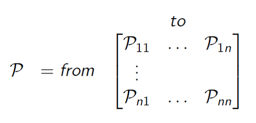

- Sum of the elements on each row yields 1

$$\sum_{j \in S}p_{ij} = 1$$

- Question: $P^2$ and $P^n$ (will discuss later)

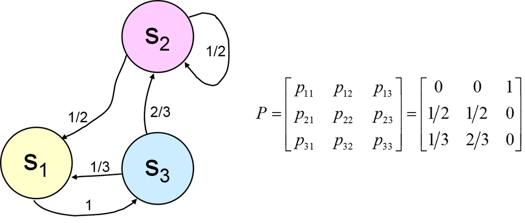

```python
import numpy as np

P = [[0, 0, 1],
    [1/2, 1/2, 0],
    [1/3, 2/3, 0]]
```

```python
print(P[1][:])
```

```
[0.5, 0.5, 0]
```

```python
a = np.random.choice(3,1,p = P[1][:])
print(a)
```

```
[1]
```

```python
# sequential processes
# sequence generated by Markov chain
# S1 = 0, S2 = 1, S3 = 2

# starting from 0
x = 0
S = []
S.append(x)

for i in range(5):
    x = np.random.choice(3,1,p = P[x][:])[0]
    S.append(x)

print(S)
```

```
[0, 2, 1, 1, 1, 1]
```

### 1.2.2. Markov Chain Components

1) a finite set of $N$ states, $S = \{ S_1, \cdots , S_N \}$

2) a state transition probability, $P = \{ p_{ij} \}_{M \times M},\quad 1 \leq i,j \leq M$

3) an initial state probability distribution, $\pi = \{ \pi_i\}$

It represents passive stochastic behavior

### 1.2.3. Example of Markov Chain

Starting from $S_1$ = Class 1

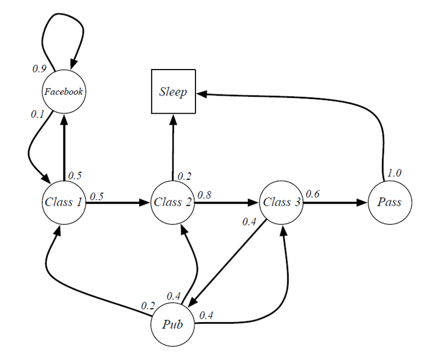

```python
P = [[0, 0.5, 0, 0, 0, 0.5, 0],
    [0, 0, 0.8, 0, 0, 0, 0.2],
    [0, 0, 0, 0.6, 0.4, 0, 0],
    [0, 0, 0, 0, 0, 0, 1],
    [0.2, 0.4, 0.4, 0, 0, 0, 0],
    [0.1, 0, 0, 0, 0, 0.9, 0],
    [0, 0, 0, 0, 0, 0, 1]]

# sequential processes
# sequence generated by Markov chain
# [C1 C2 C3 Pass Pub FB Sleep] = [0 1 2 3 4 5 6]

name = ['C1','C2','C3','Pass','Pub','FB','Sleep']

# starting from 0
x = 0
S = []
S.append(x)

for i in range(5):
    x = np.random.choice(len(P),1,p = P[x][:])[0]
    S.append(x)

print(S)
```

```
[0, 1, 2, 4, 2, 3]
```

```python
episode = []

for i in S:
    episode.append(name[i])

print(episode)
```

```
['C1', 'C2', 'C3', 'Pub', 'C3', 'Pass']
```

## 1.3. Chapman-Kolmogorov Equation

- (1-step transition probabilities) For a Markov chain on a finite state space, $S = \{ S_1, \cdots , S_N \}$, with transition probability matrix $P$ and initial distribution $\pi = \{ \pi_i^{0} \}$ (row vector) then the distribution of $X(1)$ is given by

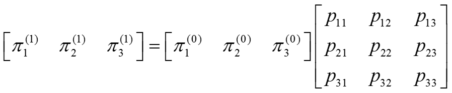

- (2-step transition probabilities) For a Markov chain on a finite state space, $S = \{ S_1, \cdots , S_N \}$, with transition probability matrix $P$ and initial distribution $\pi = \{ \pi_i^{0} \}$ (row vector) then the distribution of $X(2)$ is given by

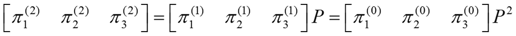

- (n-step transition probabilities) For a Markov chain on a finite state space, $S = \{ S_1, \cdots , S_N \}$, with transition probability matrix $P$ and initial distribution $\pi = \{ \pi_i^{0} \}$ (row vector) then the distribution of $X(n)$ is given by

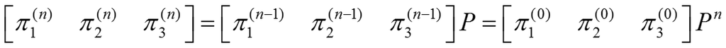

- $P^n$: n-step transition probabilities
- Key recursion

$$p_{ij}(n) = \sum_{k=1}^{N} p_{ik}(n-1) p_{kj}(1), \qquad i \rightarrow k \; \text{and}\; k \rightarrow j \;\text{imply}\; i \rightarrow j$$

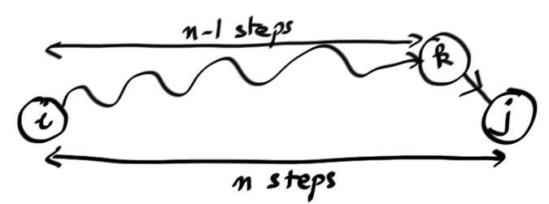

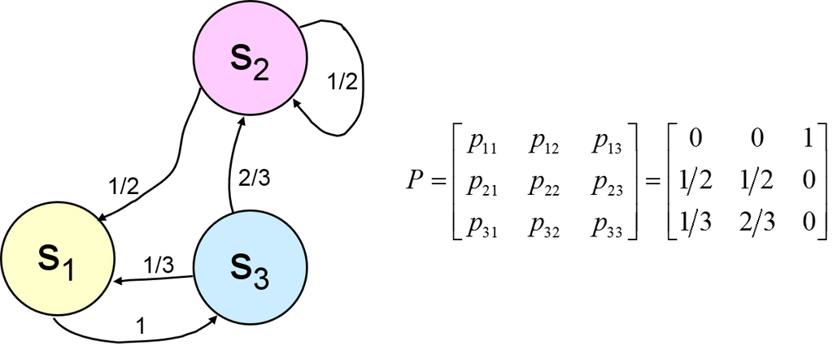

```python
# state probability distribution

P = [[0, 0, 1],
    [1/2, 1/2, 0],
    [1/3, 2/3, 0]]

u = [0, 1, 0]

P = np.asmatrix(P)
u = np.asmatrix(u)

for i in range(10):
    u = u*P
    print(u)
```

```
[[0.5 0.5 0. ]]
[[0.25 0.25 0.5 ]]
[[0.29166667 0.45833333 0.25      ]]
[[0.3125     0.39583333 0.29166667]]
[[0.29513889 0.39236111 0.3125    ]]
[[0.30034722 0.40451389 0.29513889]]
[[0.30063657 0.3990162  0.30034722]]
[[0.29962384 0.39973958 0.30063657]]
[[0.30008198 0.40029417 0.29962384]]
[[0.3000217  0.39989632 0.30008198]]
```

```python
u = [0, 1, 0]
u = u*P**10
print(u)
```

```
[[0.3000217  0.39989632 0.30008198]]
```

## 1.4. Stationary Distribution

- Steady-state behavior
- Does $p_{ij}(n)=P[X_n = j \mid X_0 = i] $ converge to some $\pi_j$ ?
- Take the limit as $n \rightarrow \infty$

$$p_{ij}(n) = \sum_{k=1}^{N} p_{ik}(n-1) p_{kj}$$$$\pi_j = \sum_{k=1}^{N} \pi_k p_{kj}$$

- Need also $\sum_j \pi_j = 1$

$$\pi = \pi P$$

- How to compute (https://brilliant.org/wiki/stationary-distributions/)
  - Eigen-analysis
  - Fixed-point iteration (we already did)

```python
# eigenvalue = 1 and associated eigenvector

d, v = np.linalg.eig(P.T)

print(d) # loof for eigenvalue = 1
```

```
[-0.25+0.32274861j -0.25-0.32274861j  1.  +0.j        ]
```

```python
print(v[:,2]/np.sum(v[:,2]))
```

```
[[0.3-0.j]
 [0.4-0.j]
 [0.3-0.j]]
```

# 2. Markov Reward Process

- Suppose that each transition in a Markov chain is associated with a reward, $r$
- As the Markov chain proceeds from state to state, there is an associated sequence of rewards
- Discount factor $\gamma$
- Later, we will study dynamic programming and Markov decision theory $\Rightarrow$ Markov Decision Process (MDP)
  - These topics include a decision maker, policy maker, or control that modify both the transition probabilities and the rewards at each trial of the Markov chain.

## 2.1. Definition of MRP

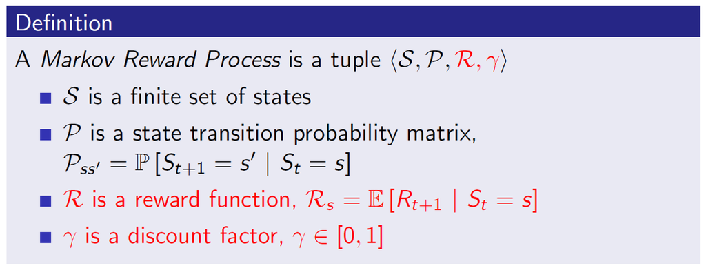

- Example: student MRP

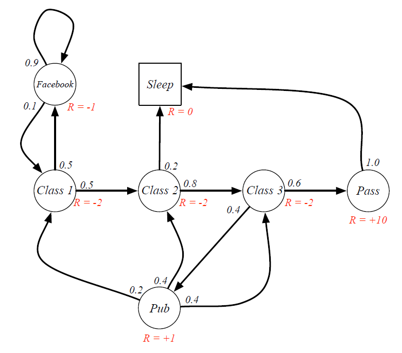

## 2.2. Reward over Multiple Transitions (= Return)

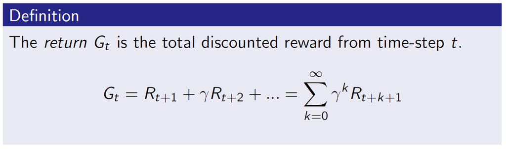

```python
# [C1 C2 C3 Pass Pub FB Sleep] = [0 1 2 3 4 5 6]

R = [-2, -2, -2, 10, 1, -1, 0]
gamma = 0.9

# if a sequence is given
S = [0, 1, 2, 4, 2, 4]

G = 0
for i in range(5):
    G = G + (gamma**i)*R[S[i]]

print(G)
```

```
-6.0032
```

```python
R = [-2, -2, -2, 10, 1, -1, 0]
gamma = 0.9

P = [[0, 0.5, 0, 0, 0, 0.5, 0],
    [0, 0, 0.8, 0, 0, 0, 0.2],
    [0, 0, 0, 0.6, 0.4, 0, 0],
    [0, 0, 0, 0, 0, 0, 1],
    [0.2, 0.4, 0.4, 0, 0, 0, 0],
    [0.1, 0, 0, 0, 0, 0.9, 0],
    [0, 0, 0, 0, 0, 0, 1]]

# sequence generated by Markov chain
# [C1 C2 C3 Pass Pub FB Sleep] = [0 1 2 3 4 5 6]

# starting from 0
x = 0
S = []
S.append(x)

for i in range(5):
    x = np.random.choice(len(P),1,p = P[x][:])[0]
    S.append(x)

G = 0
for i in range(5):
    G = G + (gamma**i)*R[S[i]]

print(S)
print(G)
```

```
[0, 5, 5, 5, 5, 0]
-5.0951
```

## 2.3. Value Function

- the value function $\upsilon (s)$ gives the long-term value of state $s$

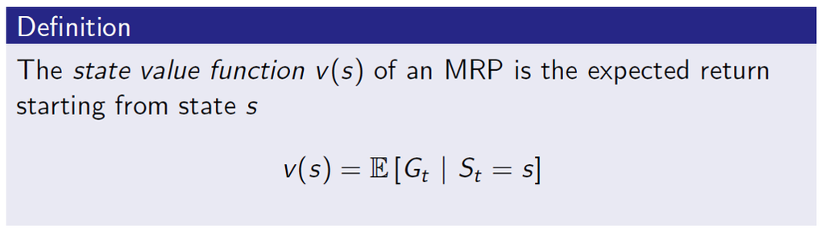

- Sample returns for student MRP: starting from $S_1 = C_1$ with $\gamma = \frac{1}{2}$

$$G_1 = R_2 + \gamma R_3 + \cdots + \gamma^{T-2} R_T$$

## 2.4. Bellman Equations for MRP (Value Iteration)

- The value function $\upsilon(S_t)$ can be decomposed into two parts:
  - Immediate reward $R_{t+1}$ at state $S_t$
  - Discounted value of successor state $\gamma \upsilon (S_{t+1})$

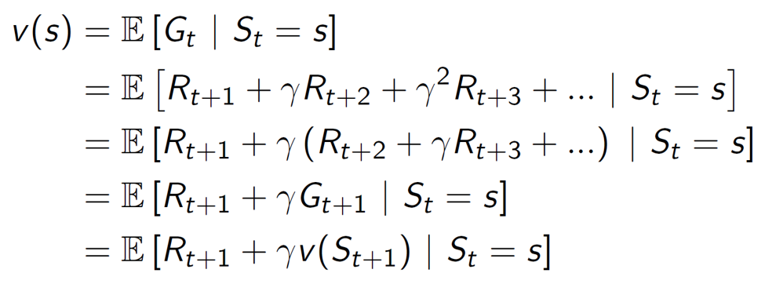

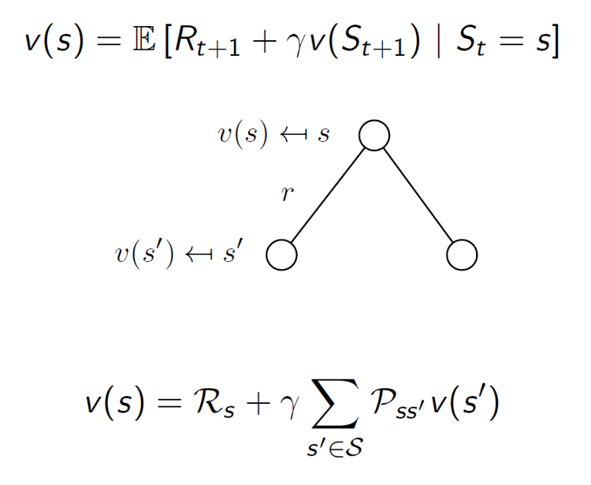

- Bellman Equation for Student MRP

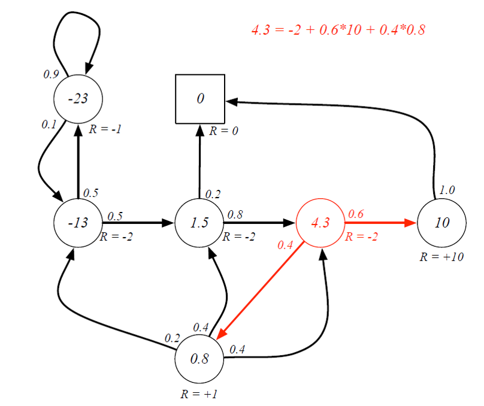

### 2.4.1. Bellman Equation in Matrix Form

The Bellman equation can be expressed concisely using matrices,

$$\upsilon = R + \gamma P \upsilon$$

where $\upsilon$ is a column vector with one entry per state

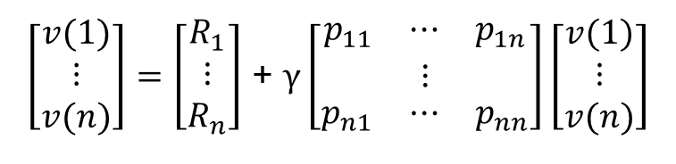

### 2.4.2. Solving the Bellman Equation

- Direct solution only possible for small MRP
- There are many iterative methods for large MRP
  - Dynamic programming
  - Monte-Carlo simulation
  - Temporal-difference learning

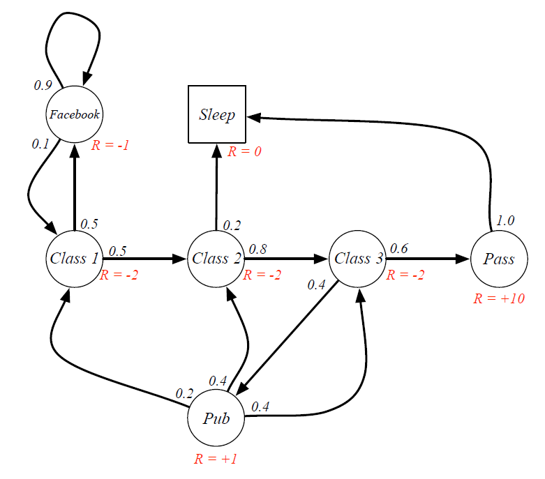

```python
# [C1 C2 C3 Pass Pub FB Sleep] = [0 1 2 3 4 5 6]

P = [[0, 0.5, 0, 0, 0, 0.5, 0],
    [0, 0, 0.8, 0, 0, 0, 0.2],
    [0, 0, 0, 0.6, 0.4, 0, 0],
    [0, 0, 0, 0, 0, 0, 1],
    [0.2, 0.4, 0.4, 0, 0, 0, 0],
    [0.1, 0, 0, 0, 0, 0.9, 0],
    [0, 0, 0, 0, 0, 0, 1]]

R = [-2, -2, -2, 10, 1, -1, 0]

P = np.asmatrix(P)
R = np.asmatrix(R)
R = R.T

gamma = 0.9
v = (np.eye(7) - gamma*P).I*R
print(v)
```

```
[[-5.01272891]
 [ 0.9426553 ]
 [ 4.08702125]
 [10.        ]
 [ 1.90839235]
 [-7.63760843]
 [ 0.        ]]
```

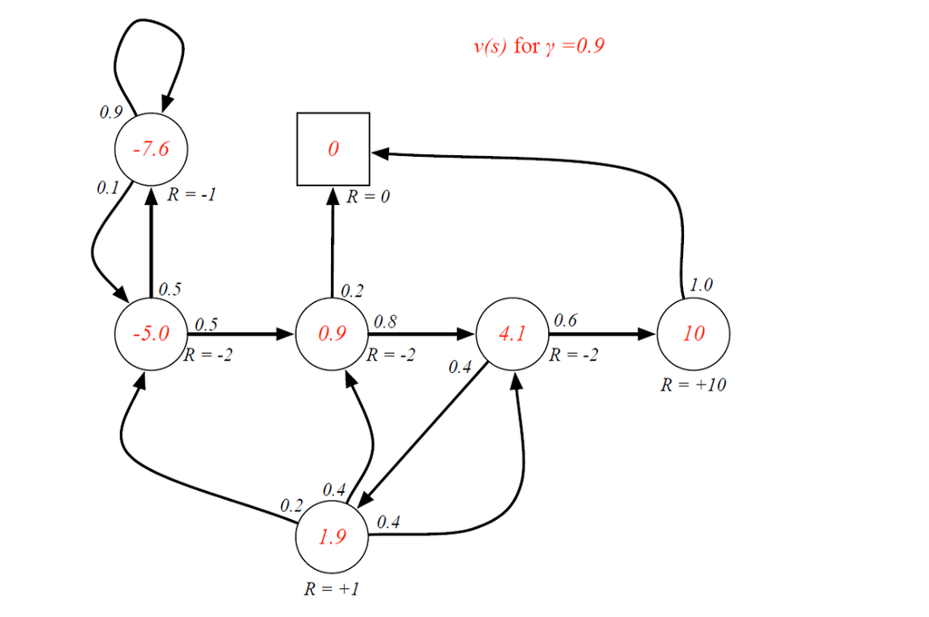

```python
gamma = 0.9

v = np.zeros([7,1])

for i in range(100):
    v = R + gamma*P*v

print(v)
```

```
[[-5.01272786]
 [ 0.94265541]
 [ 4.08702138]
 [10.        ]
 [ 1.90839268]
 [-7.63760653]
 [ 0.        ]]
```

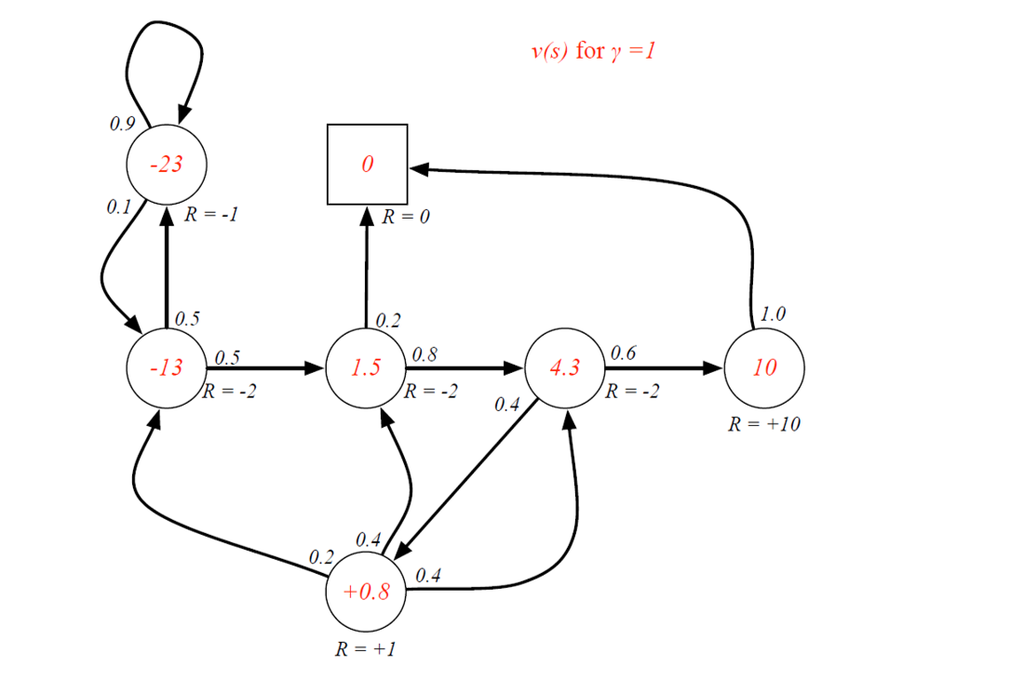

```python
gamma = 1

v = np.zeros([7,1])

for i in range(100):
    v = R + gamma*P*v

print(v)
```

```
[[-12.4182877 ]
 [  1.47030894]
 [  4.33713371]
 [ 10.        ]
 [  0.84103688]
 [-22.31800952]
 [  0.        ]]
```

# 3. Markov Decision Process

- So far, we analyzed the passive behavior of a Markov chain with rewards

## 3.1. MDP Definition

- A Markov decision process (MDP) is a Markov reward process with decisions (or actions).

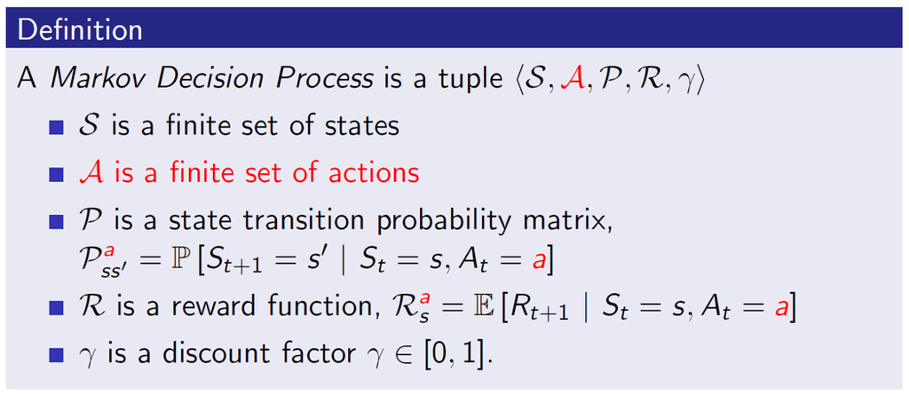

- Example: Startup MDP
  - You run a startup company. In every state, you must choose between Saving money or Advertising

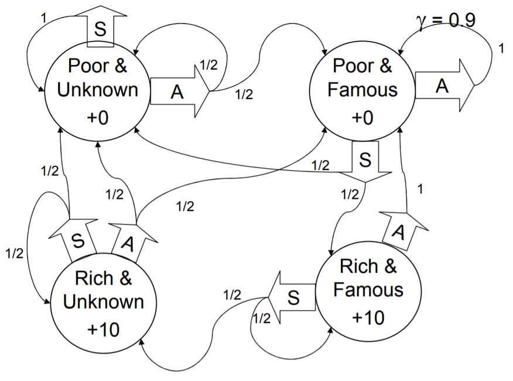

## 3.2. Policies

- A policy is a mapping from state to actions, $\pi: S \rightarrow A$
- A policy fully defines the behavior of an agent
- MDP policies depend on the current state (not the history)
- Policies are stationary (time-independent)
- Let $P^{\pi}$ be a matrix containing probabilities for each transition under policy $\pi$
- Given an MDP $\mathcal{M} = \langle S,A,P,R,\gamma \rangle$ and a policy $\pi$
  - The state sequence $s_1, s_2, \cdots $ is a Markov process $\langle S, P^{\pi} \rangle$
  - The state and reward sequence is a Markov reward process $\langle S,P^{\pi},R^{\pi},\gamma \rangle$
- Questions on MDP policy
  - How many possible policies in our example?
  - Which of the above two policies is best?
  - How do you compute the optimal policy?

### 3.2.1. Value Function

State-value function

- The state-value function $\upsilon_{\pi}(s)$ of an MDP is the exptected return starting from state $s$, and then following policy $\pi$

$$\upsilon_{\pi}(s) = \mathbb{E} \left[G_t \mid S_t =s \right]$$

### 3.2.2. Bellman Expectation Equation

- Given the policy $\pi$, the state-value function can again be decomposed into immediate reward plus discounted value of successor state

$$ \upsilon_{\pi}(s) = \mathbb{E}_{\pi}[ R_{t+1} + \gamma \upsilon_{\pi}(S_{t+1}) \mid S_t = s ] \quad \implies \quad \upsilon_{\pi} (s) = R(s) + \gamma \sum_{s' \in S} P_{s s'}^{\pi} \;\upsilon_{\pi} \left(s' \right)$$

- The Bellman expectation equation can be expressed concisely in a matrix form,

$$\upsilon_{\pi} = R + \gamma \, P^{\pi} \,\upsilon_{\pi} \quad \implies \quad \upsilon_{\pi} = (I - \gamma \,P^{\pi})^{-1}R $$

### 3.2.3. Two examples

- Given the policy 1, it is MRP

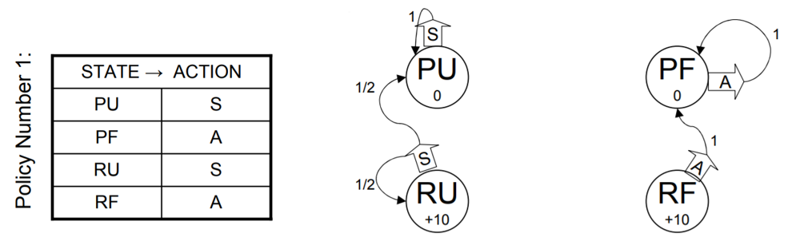

```python
# [PU PF RU RF] = [0 1 2 3]

import numpy as np

P = [[1, 0, 0, 0],
    [0, 1, 0, 0],
    [0.5, 0, 0.5, 0],
    [0, 1, 0, 0]]

R = [0, 0, 10, 10]

P = np.asmatrix(P)
R = np.asmatrix(R)
R = R.T

gamma = 0.9
v = (np.eye(4) - gamma*P).I*R
print(v)
```

```
[[ 0.        ]
 [ 0.        ]
 [18.18181818]
 [10.        ]]
```

```python
v = np.zeros([4,1])

for i in range(100):
    v = R + gamma*P*v

print(v)
```

```
[[ 0.        ]
 [ 0.        ]
 [18.18181818]
 [10.        ]]
```

- Given the policy 2, it is MRP

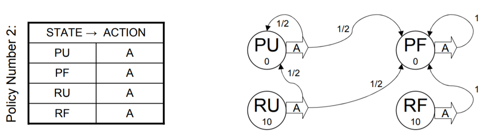

```python
# [PU PF RU RF] = [0 1 2 3]

import numpy as np

P = [[0.5, 0.5, 0, 0],
    [0, 1, 0, 0],
    [0.5, 0.5, 0, 0],
    [0, 1, 0, 0]]

R = [0, 0, 10, 10]

P = np.asmatrix(P)
R = np.asmatrix(R)
R = R.T

gamma = 0.9
v = (np.eye(4) - gamma*P).I*R
print(v)
```

```
[[ 0.]
 [ 0.]
 [10.]
 [10.]]
```

```python
v = np.zeros([4,1])

for i in range(100):
    v = R + gamma*P*v

print(v)
```

```
[[ 0.]
 [ 0.]
 [10.]
 [10.]]
```

## 3.3. Optimal Policy

- The optimal policy is the policy that achieves the highest value for every state

$$\pi^*(s) = \arg\max_{\pi} \upsilon_{\pi}(s)$$

$\quad \;\;$and its optimal value function is written $\upsilon^*(s)$

- We can directly define the optimal value function using Bellman optimality equation

$$\upsilon^* (s) = R(s) + \gamma \max_{a} \sum_{s' \in S} P_{s s'}^{a} \;\upsilon^* \left(s' \right)$$

$\quad \;\;$and optimal policy is simply the action that attains this max

$$\pi^*(s) = \arg\max_{a} \sum_{s' \in S} P_{s s'}^{a} \, \upsilon^*_{\pi}(s')$$

## 3.4.Value iteration

1) initialize an estimate for the value function arbitrarily

$$ v(s) \leftarrow 0 \quad \forall s \in S $$

2) Repeat, update

$$\upsilon (s) \leftarrow R(s) + \gamma \max_{a} \sum_{s' \in S} P_{s s'}^{a} \;\upsilon \left(s' \right), \quad \forall s \in S$$

**Example**

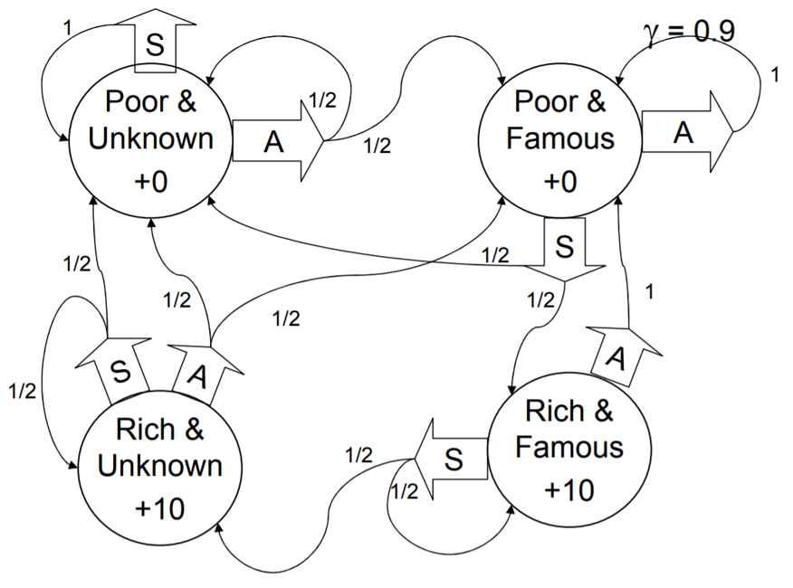

**Define MDP as a two-level dictionary**

`P` is a two-level dictionary where the first key is the state and the second key is the action.

- State indices `[0, 1, 2, 3]` correspond to [PU, PF, RU, RF]
- Action indices `[0, 1]` correspond to [Saving momey, Advertising]

`P[state][action]` is a list of tuples `(probability, nextstate)`.

For example,

- the transition information for s = 0, a = 0 is `P[0][0] = [(1, 0)]`
- the transition information for s = 3, a = 0 is `P[3][0] = [(0.5, 2), (0.5, 3)]`

```python
P = {
 0: {0: [(1, 0)], 1: [(0.5, 0), (0.5, 1)]},
 1: {0: [(0.5, 0), (0.5, 3)], 1: [(1, 1)]},
 2: {0: [(0.5, 0), (0.5, 2)], 1: [(0.5, 0), (0.5, 1)]},
 3: {0: [(0.5, 2), (0.5, 3)], 1: [(1, 1)]},
}

R = [0, 0, 10, 10]
gamma = 0.9

States = [0, 1, 2, 3]
Actions = [0, 1]

v = [0]*4
```

$$\sum_{s' \in S} P_{s s'}^{a} \;\upsilon \left(s' \right)$$

```python
P[2][0]
```

```
[(0.5, 0), (0.5, 2)]
```

```python
# compute the above summation

v = [0, 0, 10, 10]

temp = 0
for trans in P[2][0]:
    temp = temp + trans[0]*v[trans[1]]

print(temp)
```

```
5.0
```

```python
# shorten

sum(trans[0]*v[trans[1]] for trans in P[2][0])
```

```
5.0
```

**Value iteratoin**

$$\upsilon (s) = R(s) + \gamma \max_{a} \sum_{s' \in S} P_{s s'}^{a} \;\upsilon \left(s' \right)$$

1) initialize an estimate for the value function arbitrarily

$$ v(s) \leftarrow 0 \quad \forall s \in S $$

2) Repeat, update

$$\upsilon (s) \leftarrow R(s) + \gamma \max_{a} \sum_{s' \in S} P_{s s'}^{a} \;\upsilon \left(s' \right), \quad \forall s \in S$$

```python
v = [0]*4
```

```python
# optimal value fuction

for i in range(100):
    for s in States:
        q_0 = sum(trans[0]*v[trans[1]] for trans in P[s][0])
        q_1 = sum(trans[0]*v[trans[1]] for trans in P[s][1])

        v[s] = R[s] + gamma*max(q_0, q_1)

print(v)
```

```
[31.58508953413495, 38.60400287377479, 44.02416232966445, 54.20158563176306]
```

**Optimal policy**

$$\pi^*(s) = \arg\max_{a} \sum_{s' \in S} P_{s s'}^{a} \, \upsilon_{\pi}(s')$$

```python
# optimal policy

# once v computed

optPolicy = [0]*4

for s in States:
    q_0 = sum(trans[0]*v[trans[1]] for trans in P[s][0])
    q_1 = sum(trans[0]*v[trans[1]] for trans in P[s][1])

    optPolicy[s] = np.argmax([q_0, q_1])

print(optPolicy)
```

```
[1, 0, 0, 0]
```

```python
# shorten

v = [0]*4
```

```python
for i in range(100):
    for s in States:
        v[s] = R[s] + gamma*max([sum([trans[0]*v[trans[1]] for trans in P[s][a]]) for a in Actions])

print(v)
```

```
[31.58508953413495, 38.60400287377479, 44.02416232966445, 54.20158563176306]
```

```python
optPolicy = [0]*4

for s in States:
    optPolicy[s] = np.argmax([sum([trans[0]*v[trans[1]] for trans in P[s][a]]) for a in Actions])

print(optPolicy)
```

```
[1, 0, 0, 0]
```

## 3.5. Solving the Bellman Optimality Equation

- Bellman Optimality Equation is non-linear
- No closed form solution (in general)
- (Will learn later) many iterative solution methods
  - Value Iteration
  - Policy Iteration
  - Q-learning
  - SARSA
- You will get into details in the course of reinforcement learning

# 4. Exercise (Gridworld Domain)

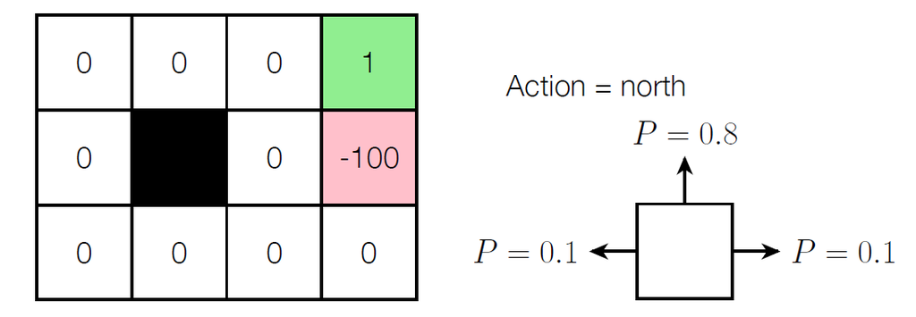

```python
P = {
 0: {0: [(0.9,0),(0.1,1),(0,4)], 1: [(0.8,1),(0.1,4),(0.1,0)], 2: [(0.8,4),(0.1,1),(0.1,0)], 3: [(0.9,0),(0.1,4)]},
 1: {0: [(0.8,1),(0.1,2),(0.1,0)], 1: [(0.8,2),(0.2,1)], 2: [(0.8,1),(0.1,0),(0.1,2)], 3: [(0.8,0),(0.2,1)]},
 2: {0: [(0.8,2),(0.1,3),(0.1,1)], 1: [(0.8,3),(0.1,5),(0.1,2)], 2: [(0.8,5),(0.1,1),(0.1,3)], 3: [(0.8,1),(0.1,2),(0.1,5)]},
 3: {0: [(0.9,3),(0.1,2)], 1: [(0.9,3),(0.1,6)], 2: [(0.8,6),(0.1,2),(0.1,3)], 3: [(0.8,2),(0.1,3),(0.1,6)]},
 4: {0: [(0.8,0),(0.2,4)], 1: [(0.8,4),(0.1,7),(0.1,0)], 2: [(0.8,7),(0.2,4)], 3: [(0.8,4),(0.1,0),(0.1,7)]},
 5: {0: [(0.8,2),(0.1,6),(0.1,5)], 1: [(0.8,6),(0.1,9),(0.1,2)], 2: [(0.8,9),(0.1,5),(0.1,6)], 3: [(0.8,5),(0.1,2),(0.1,9)]},
 6: {0: [(0.8,3),(0.1,6),(0.1,5)], 1: [(0.8,6),(0.1,10),(0.1,3)], 2: [(0.8,10),(0.1,5),(0.1,6)], 3: [(0.8,5),(0.1,3),(0.1,10)]},
 7: {0: [(0.8,4),(0.1,8),(0.1,7)], 1: [(0.8,8),(0.1,7),(0.1,4)], 2: [(0.9,7),(0.1,8)], 3: [(0.9,7),(0.1,4)]},
 8: {0: [(0.8,8),(0.1,9),(0.1,7)], 1: [(0.8,9),(0.2,8)], 2: [(0.8,8),(0.1,7),(0.1,9)], 3: [(0.8,7),(0.2,8)]},
 9: {0: [(0.8,5),(0.1,10),(0.1,8)], 1: [(0.8,9),(0.1,9),(0.1,5)], 2: [(0.8,9),(0.1,8),(0.1,10)], 3: [(0.8,8),(0.1,5),(0.1,9)]},
 10: {0: [(0.8,6),(0.1,10),(0.1,9)], 1: [(0.9,10),(0.1,6)], 2: [(0.9,10),(0.1,9)], 3: [(0.8,9),(0.1,6),(0.1,10)]}
}

R = [0, 0, 0, 1, 0, 0, -100, 0, 0, 0, 0]
gamma = 0.9

States = [0, 1, 2, 3, 4, 5, 6, 7, 8, 9, 10]
Actions = [0, 1, 2, 3] # [north, east, south, west]

v = [0]*11
```

```python
# optimal value fuction

for i in range(100):
    for s in States:
        q_0 = sum(trans[0]*v[trans[1]] for trans in P[s][0])
        q_1 = sum(trans[0]*v[trans[1]] for trans in P[s][1])
        q_2 = sum(trans[0]*v[trans[1]] for trans in P[s][2])
        q_3 = sum(trans[0]*v[trans[1]] for trans in P[s][3])

        v[s] = R[s] + gamma*max(q_0, q_1, q_2, q_3)

print(v)
```

```
[5.46991289990088, 6.313016781079707, 7.189835364530538, 8.668832766371658, 4.8028486314273, 3.346646443535637, -96.67286272722137, 4.161433444369266, 3.6539401768050603, 3.2220160316109103, 1.526193402980731]
```

```python
# optimal policy

# once v computed

optPolicy = [0]*11

for s in States:
    optPolicy[s] = np.argmax([sum([trans[0]*v[trans[1]] for trans in P[s][a]]) for a in Actions])

print(optPolicy)
```

```
[1, 1, 1, 0, 0, 3, 3, 0, 3, 3, 2]
```

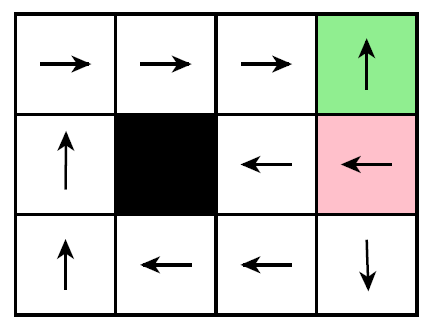